# Machine_Learning

# Predicting how well participants exercised using random forests

## By: Pooja Pancholi

## Summary

The purpose of this document it to take personal workout data and create a prediction model based on workout movements of 6 participants. The model will predict how well a person is working out based on movements of their arms, forearms, belt, and dumbbells. The 6 participants were asked to perform unilateral dumbbell biceps curls using five different maneuvers, which were represented under the variable, classe. Classe was separated into 5 factor levels, A represents working out exactly according to specification (the correct way), B represents throwing the elbows to the front (incorrect), C represents lifting the dumbbell only halfway (incorrect), D represents lowering the dumbbell only halfway (incorrect), and E represents throwing the hips in the front. Measurements were taken to see how participants moved in the x,y,z-plane for each different maneuver, which is what will be used to build the prediction algorithm. The data was collected by a research and development team from Groupware@les. More information regarding the data can be found at the following link :http://groupware.les.inf.puc-rio.br/har.

## Downloading the Data and loading necessary packages

```r
training <- read.csv("pml-training.csv")
testing <- read.csv("pml-testing.csv")
library(caret)
library(randomForest)
```

## Cleaning the Data

Only data collected from the accelerometer will be relevant in the prediction model. When looking at the data,it was clear that many of the variances had NAs. While this could have been dealt with by imputing the data, I felt that the variances may not have been necessary in building a prediction model. My assumption was that they were the variances on the total acceleration for each part measured (arms, forearms, etc.), but this can be calculated manually, if necessary.

```r
training1 <- cbind(training[grep("accel" , colnames(training))], training["classe"])
testing1 <- cbind(testing[grep("accel", colnames(testing))], testing["user_name"])
training1 <- training1[-grep("var", colnames(training1))]
testing1 <- testing1[-grep("var", colnames(testing1))]
```

## Creating the Prediction algorithm

I’ve decided to use a random forest to create the predictive model. However, when looking at the testing set, it became apparent that that set did not contain a classe variable, indicating that another testing set would be necessary to get a better sampling error of the prediction model.

```r
inTrain <- createDataPartition(y = training1$classe, p = .3, list = F)
training2 <- training1[inTrain,]
testing2 <- training1[-inTrain,]
randomf <- train(classe~., data = training2, method = "rf", trControl=trainControl(method = "cv", number = 5), prox =T, allowParallel = T)
randomf$finalModel
```

```
##
## Call:
##  randomForest(x = x, y = y, mtry = param$mtry, proximity = ..1,      allowParallel = ..2)
##                Type of random forest: classification
##                      Number of trees: 500
## No. of variables tried at each split: 2
##
##         OOB estimate of  error rate: 9%
## Confusion matrix:
##      A   B   C   D    E class.error
## A 1577  20  27  46    4  0.05794504
## B   84 964  64  11   17  0.15438596
## C   32  38 940  14    3  0.08471276
## D   27   9  53 869    7  0.09948187
## E    8  26  19  21 1009  0.06832872
```

```r
head(getTree(randomf$finalModel), 10)
```

```
##    left daughter right daughter split var split point status prediction
## 1              2              3         1        21.5      1          0
## 2              4              5         9        29.5      1          0
## 3              0              0         0         0.0     -1          5
## 4              6              7         9         4.5      1          0
## 5              8              9        11       222.5      1          0
## 6             10             11        11         1.5      1          0
## 7             12             13         3        40.5      1          0
## 8             14             15        13        40.5      1          0
## 9             16             17         4        25.5      1          0
## 10            18             19         2       -23.5      1          0
```

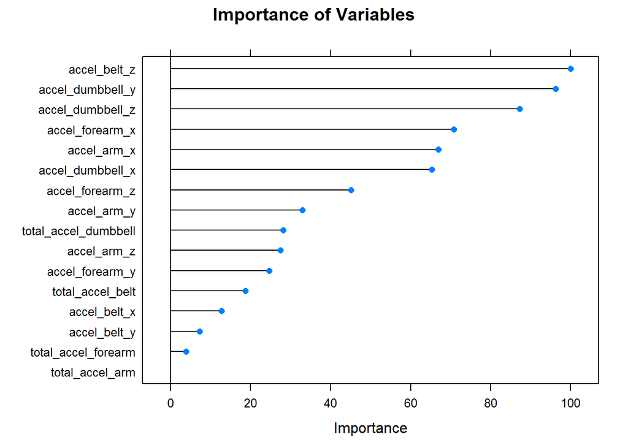

```r
plot(varImp(randomf), main = "Importance of Variables")
```

```r
randomf
```

```
## Random Forest
##
## 5889 samples
##   16 predictor
##    5 classes: 'A', 'B', 'C', 'D', 'E'
##
## No pre-processing
## Resampling: Cross-Validated (5 fold)
## Summary of sample sizes: 4711, 4711, 4711, 4711, 4712
## Resampling results across tuning parameters:
##
##   mtry  Accuracy   Kappa      Accuracy SD  Kappa SD
##    2    0.9001555  0.8736041  0.009918626  0.01254805
##    9    0.8938718  0.8656593  0.008817222  0.01110183
##   16    0.8806273  0.8488828  0.010701746  0.01344191
##
## Accuracy was used to select the optimal model using  the largest value.
## The final value used for the model was mtry = 2.
```

## Predicting on test set

I will use the set testing2 to check how well the prediction model on an outside test.

```r
pred <- predict(randomf,testing2)
testing2$predRight <- pred == testing2$classe
confusionMatrix(pred, testing2$classe)
```

```
## Confusion Matrix and Statistics
##
##           Reference
## Prediction    A    B    C    D    E
##          A 3673  182   56   87   11
##          B   36 2262   87   17   83
##          C   80  163 2211  117   46
##          D  115   34   36 2011   52
##          E    2   16    5   19 2332
##
## Overall Statistics
##
##                Accuracy : 0.9094
##                  95% CI : (0.9045, 0.9142)
##     No Information Rate : 0.2844
##     P-Value [Acc > NIR] : < 2.2e-16
##
##                   Kappa : 0.8854
##  Mcnemar's Test P-Value : < 2.2e-16
##
## Statistics by Class:
##
##                      Class: A Class: B Class: C Class: D Class: E
## Sensitivity            0.9403   0.8513   0.9232   0.8934   0.9239
## Specificity            0.9658   0.9799   0.9642   0.9794   0.9963
## Pos Pred Value         0.9162   0.9103   0.8449   0.8946   0.9823
## Neg Pred Value         0.9760   0.9649   0.9834   0.9791   0.9831
## Prevalence             0.2844   0.1935   0.1744   0.1639   0.1838
## Detection Rate         0.2675   0.1647   0.1610   0.1464   0.1698
## Detection Prevalence   0.2919   0.1810   0.1906   0.1637   0.1729
## Balanced Accuracy      0.9531   0.9156   0.9437   0.9364   0.9601
```

## Out-of-Sample error rate

```r
1 - sum(diag(table(pred, testing2$classe)))/sum(table(pred, testing2$classe))
```

```
## [1] 0.09058472
```